# A/B testing Using Customer Visits Data

# Libraries

```r
library(tidyverse)
library(powerMediation)
library("knitr")
```

```r
themeSajjad <-
  theme(axis.text = element_text(size = 20),
  axis.title = element_text(size = 17),
  legend.title=element_text(size=20),
  legend.text = element_text(size = 20),
  axis.title.y = element_text(margin = margin(t = 0, r = 20, b = 0, l = 0)))
```

# Read data

```r
z <- read_csv(paste0(here::here(), "/ab_data.csv"))
```

```r
x <- z
```

# Missing values

```r
nMiss <- function(x) sum(is.na(x))

x %>%
  summarise_all(nMiss)
```

```
## # A tibble: 1 x 5
##   user_id timestamp group landing_page converted
##     <int>     <int> <int>        <int>     <int>
## 1       0         0     0            0         0
```

No missing values.

# Exploring convertion rate across groups

```r
x %>%
  group_by(group) %>%
  summarise(n = n(), conversionRate = mean(converted))
```

```
## # A tibble: 2 x 3
##   group          n conversionRate
##   <chr>      <int>          <dbl>
## 1 control   147202          0.120
## 2 treatment 147276          0.119
```

There are 147202 users in the control group and 147276 users in the treatment group.

The average conversion rate for the is 0.12 for the control group and 0.119 for the treatment group.

# A/B test (Checking effect of group on conversion rate)

We want to develop a Logistic Regression model to evaluate the effects of groups assigned to users in their conversion rate. Before running the model we need to make sure we adjust the model for other factors that might have affected the rate of conversion. In the dataset we timestamp and landing_page that both could potentially affect the conversion rate as different month could have different user interest rate and landing_pages are different and one cannot compare effect of groups on conversion rate for differnt landing_page`s.

Let’s first check how conversion rate changes in different landing pages.

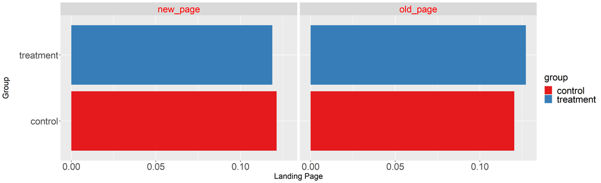

```r
x %>%
  group_by(group, landing_page) %>%
  summarise(m = mean(converted)) %>%
  ggplot(aes(x = group, y = m, fill = group))+
  geom_bar(stat = "identity")+
  labs(x = "Group", y = "Landing Page")+
  scale_fill_brewer(palette = "Set1")+
  coord_flip()+
  themeSajjad+
  facet_grid(~landing_page)+
  theme(strip.text.x = element_text(size = 20, colour = "red", angle = 0))
```

And now check how conversion rate changes through time. For simplicty I only consider effect of date and will remove time of the day from the datetime object.

```r
x <- x %>%
  mutate(date = as.Date(format(timestamp, "%Y-%m-%d"), "%Y-%m-%d" ))
```

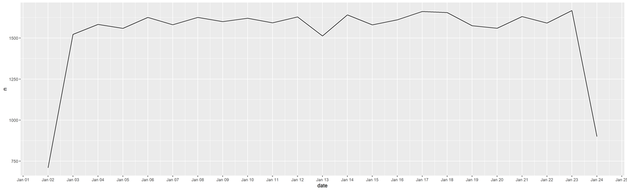

```r
x %>%
  group_by(date) %>%
  mutate(n = sum(converted)) %>%
  ggplot(aes(x = date, y = n))+
  geom_line(stat = "identity")+
  scale_x_date(date_labels = "%b %d", date_breaks = "1 day")
```

```r
x %>%
  filter(date %in% c(as.Date("2017-01-02", "%Y-%m-%d"),
                     as.Date("2017-01-24", "%Y-%m-%d"))) %>%
  group_by(group) %>%
  summarise(m = mean(converted))
```

```
## # A tibble: 2 x 2
##   group         m
##   <chr>     <dbl>
## 1 control   0.121
## 2 treatment 0.120
```

The average conversion rate for those two days are similar to the rest of the dataset, so we can assume the conversion rate has been the same across the study period and do not include date in the model.

Let’s now build our Logistic Regression model which only inclues group and landing_page variables. Here’s our hypothesis for this test:

$H_{0}: P_{control} = P_{treatment}$ $H_{a}: P_{control} < P_{treatment}$

```r
x <- x %>% mutate(converted = factor(converted, levels = c(0, 1)))
lrModel <- glm(converted ~ group + landing_page, data = x, family = "binomial")

summary(lrModel)
```

```
##
## Call:
## glm(formula = converted ~ group + landing_page, family = "binomial",
##     data = x)
##
## Deviance Residuals:
##     Min       1Q   Median       3Q      Max
## -0.5116  -0.5066  -0.5031  -0.5031   2.0727
##
## Coefficients:
##                      Estimate Std. Error z value            Pr(>|z|)
## (Intercept)          -2.02391    0.04972 -40.708 <0.0000000000000002 ***
## grouptreatment        0.02072    0.04970   0.417               0.677
## landing_pageold_page  0.03571    0.04970   0.719               0.472
## ---
## Signif. codes:  0 '***' 0.001 '**' 0.01 '*' 0.05 '.' 0.1 ' ' 1
##
## (Dispersion parameter for binomial family taken to be 1)
##
##     Null deviance: 215702  on 294477  degrees of freedom
## Residual deviance: 215700  on 294475  degrees of freedom
## AIC: 215706
##
## Number of Fisher Scoring iterations: 4
```

Looking at the p values of the model, we don’t have sufficient evidence to reject the null hypothesis. In the context of our test, this means that there is not enough statistical evidence in our survey to show a difference in the rate of conversion between two different groups, when adjusted for landing page.